# Resultados - artigo

Mori, Danilo Pereira

21 de maio de 2018

## Estrutura dos Resultados Completos:

1. parâmetros de dispersão:
1. distância média de dispersão (d)
2. número fundamental da dispersão (I)
- com isso podemos avaliar quais as situações biológicas de limitação à dispersão que a simulação está ocorrendo para os dois modelos neutros
2. Congruência do predito com o observado
- a ideia central do artigo é: “Avaliar se a SAD pode ser evidência suficiente para refutar neutralidade”
- assim optei por mudar a variável de congruência de GOF, que avalia quantas predições neutras foram refutadas por cenário neutro
- para n_ref = número de predições neutras refutadas por cenário neutro
3. taxa de especiação necessária para manter a riqueza observada no equilíbrio dinâmico segundo um modelo neutro espacialmente explícito (U)
- a teoria neutra pode ser uma boa aproximaçaõ para descrever a taxa de extinção de espécies raras em ambientes fragmentados
- o modelo neutro coalescente é uma boa aproximação para descrever o comportamento dos sistemas biológicos em diferentes contextos de fragmentação (Campos et al.)
- no modelo coalescente o equilíbrio dinâmico é observado, nesse cenário a taxa de surgimento de singletons por evento de morte se igual à taxa de extinção de singletons
- assim, a estimativa de taxa de especiação necessária para manter a riqueza observada no equilíbrio pode ser uma aproximação da taxa de extinção das espécies raras na paisagem.
4. Anexo 1: código auxiliar
- segue a mesma ordem das variáveis
- é o local onde eu desenvolvo a análise dos dados

Notas: até o momento desenvolvi parte da análise dos dados para I.A

#### Anexo 1: código auxiliar

##### I) parâmetros de dispersão

**I.A) distância média de dispersão (d)**

Exploração gráfica

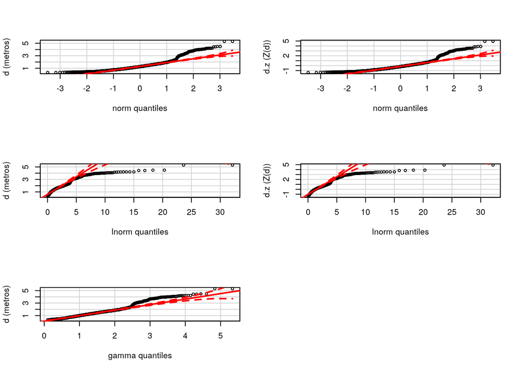

Figura A1. Gráficos quantile-quantile para três distribuições teóricas (normal, lognormal e gamma) e a variável d (metros) e z-transformada (d.z). Para a distribuição gamma utilizei ajustamos apenas a variável d, uma vez que o domínio da distribuição não contempla valores menores do que zero.

A distribuição que melhor se adequa aos dados é a distribuição gamma: i) ajusta maior porção dos dados em comparação com a normal (segunda melhor distribuição) e ii) consegue capturar a variação nas caudas da distribuição de valores obervados (em especial para valores pequenos), diferente da normal. Contudo, para comparar os resíduos eu vou construir duas classes de modelos cheio: uma normal e outra gamma.

O objetivo é avaliar o efeito da variável k na distância média de dispersão (d), para isso o modelo cheio vai considerar a variável DA, uma vez que k é definido como a proporção de propágulos até l_cel metros da planta progenitora. A largura da célula de simulação (l_cel) = 100/sqrt(DA) (PERGUNTA:devo utilizar DA ou a transformação de DA = I( 100/sqrt(DA) )? ).

*Tabela Seleção da distribuição de probabiliade e estrutura aleatória*

```
##                   dAICc   df weight
## log.Gamma 1|Site      0.0 15 1
## log.normal 1|Site   604.2 15 <0.001
## log.normal k|Site 10842.8 7  <0.001
## Gamma 1|Site      11387.8 15 <0.001
## log.Gamma k|Site  12680.8 7  <0.001
## normal 1|Site     12744.7 15 <0.001
## normal k|Site     14332.5 7  <0.001
## Gamma k|Site      15364.5 7  <0.001
```

O modelo global com distribuição gamma, função de ligação log e estrutura aleatória 1|Site foi o mais plausível. Segue sumário:

```r
summary(l_md[[3]])  # problema de convergência, indicam para reescalonar as variáveis
```

```
## Generalized linear mixed model fit by maximum likelihood (Laplace
##   Approximation) [glmerMod]
##  Family: Gamma  ( log )
## Formula: d ~ k + DA.z + (1 | Site)
##    Data: df_resultados
##
##      AIC      BIC   logLik deviance df.resid
## -15328.7 -15245.3   7679.4 -15358.7     1905
##
## Scaled residuals:
##      Min       1Q   Median       3Q      Max
## -2.26433 -0.42864  0.01477  0.41446  2.34762
##
## Random effects:
##  Groups   Name        Variance  Std.Dev.
##  Site     (Intercept) 6.708e-05 0.008190
##  Residual             2.511e-05 0.005011
## Number of obs: 1920, groups:  Site, 80
##
## Fixed effects:
##               Estimate Std. Error t value Pr(>|z|)
## (Intercept) -0.7339162  0.0048757    -151   <2e-16 ***
## k0.95        0.3474246  0.0003663     948   <2e-16 ***
## k0.9         0.5510719  0.0003663    1504   <2e-16 ***
## k0.85        0.6962732  0.0003663    1901   <2e-16 ***
## k0.8         0.8183672  0.0003663    2234   <2e-16 ***
## k0.75        0.9258117  0.0003663    2527   <2e-16 ***
## k0.7         1.0255610  0.0003663    2800   <2e-16 ***
## k0.65        1.1217737  0.0003663    3062   <2e-16 ***
## k0.6         1.2153339  0.0003663    3318   <2e-16 ***
## k0.55        1.3096451  0.0003663    3575   <2e-16 ***
## k0.5         1.4044359  0.0003663    3834   <2e-16 ***
## k0.25        1.9657591  0.0003663    5366   <2e-16 ***
## DA.z        -0.1448211  0.0048741     -30   <2e-16 ***
## ---
## Signif. codes:  0 '***' 0.001 '**' 0.01 '*' 0.05 '.' 0.1 ' ' 1
```

```
##
## Correlation matrix not shown by default, as p = 13 > 12.
## Use print(x, correlation=TRUE)  or
##   vcov(x)     if you need it
```

```
## convergence code: 0
## Model is nearly unidentifiable: very large eigenvalue
##  - Rescale variables?
```

*31jun2018* - Problema de convergência: convergence code: 0 Model is nearly unidentifiable: very large eigenvalue - Rescale variables? ajuda: ?convergence

" if you do see convergence warnings, and want to trouble-shoot/double-check the results, the following steps are recommended (examples are given below):

double-check the model specification and the data for mistakes

center and scale continuous predictor variables (e.g. with scale)

check for singularity: if any of the diagonal elements of the Cholesky factor are zero or very small, the convergence testing methods may be inappropriate (see examples)

double-check the Hessian calculation with the more expensive Richardson extrapolation method (see examples)

restart the fit from the apparent optimum, or from a point perturbed slightly away from the optimum

try all available optimizers (e.g. several different implementations of BOBYQA and Nelder-Mead, L-BFGS-B from optim, nlminb, …) via the allFit() function, see ‘5.’ in the examples. While this will of course be slow for large fits, we consider it the gold standard; if all optimizers converge to values that are practically equivalent, then we would consider the convergence warnings to be false positives. "

A única variável contínua que não foi rescalonada foi a resposta d, se aplicar transformação z em d, a variável resposta terá números negativos. Utilizando a variável DA ao inves de DA.z piora o caso. Alternativamente busquei simplificar o modelo: a) retirando a variável DA.z; e b) retirando o último nível de k (contudo como é um factor não há de fazer muita diferença) - para ambos não houve melhora.

PRÓXIMOS PASSOS PARA MELHORAR AJUSTE: uma alternativa fácil é reajustar a partir das estimativas feitas pelo modelo com problema de convergência e/ou modificar o otimizador. PERGUNTAS NORTEADORAS: i) o aviso de problema de convergência é um falso positivo?

Ben Bolker: Since the likelihood differs by <0.1 between the model fits, and the largest relative differences in the parameters are of the order of about 10^(-4), I would say that you have successfully demonstrated that the warning is a false positive and you can proceed with your initial model.

25jun2018: Para lidar com b modifiquei DA -> DA.z nos modelos globais Com isso obtive o erro: ’converge code:0; Model is nearly unidentifiable: very large eigenvalue - Rescale variables? - a transformação z de DA deveria ser o suficiente para lidar com problemas relacionados com escalamento de variáveis; a outra variável explanatória é categórica. - vou continuar o estudo com esse modelo como global

*Tabela Selecao de variaveis esplanatorias para descrever ‘d’*

```
##      dAICc   df
## k+DA     0.0 15
## k      123.6 14
## DA   19032.9 4
## 1    19132.3 3
```

O modelo global foi o mais plausível. [PROBLEMA DE CONVERGÊNCIA]. E por conta disso não consigo avaliar o ajuste visualmente:

```r
# prof_glmm.d <- profile(l_md[[3]])

# xyplot(prof_glmm.d , aspect =1.3)
```

Avaliação gráfica do ajuste do modelo:

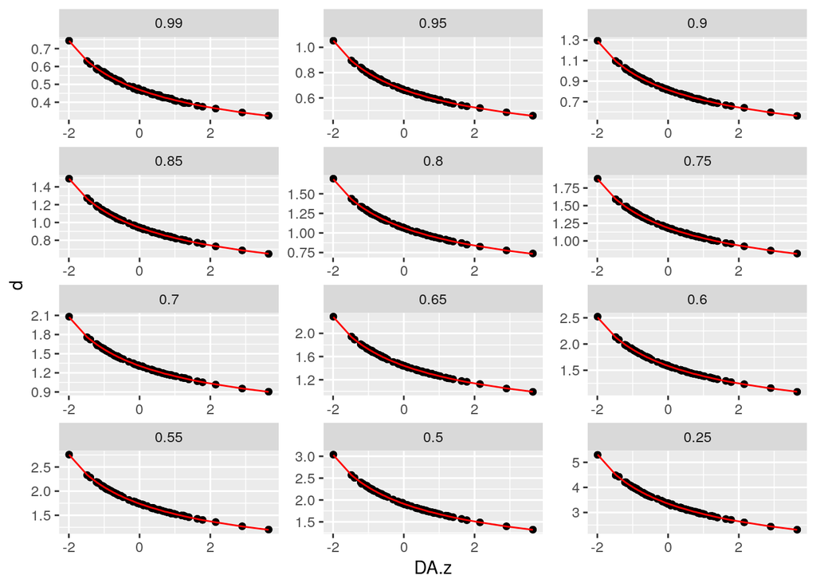

**Figura 1** Distância média de dispersão (d) e o predito segundo d ~ DA.z + k + (1 | Sítio), family=Gamma. Os pontos são as distâncias médias estimados para o determinado percentil (k) de propágulos que permanecem até l_cel metros da planta progenitora; em vermelho o predito.

Parece que há boa congruência entre o observado e o predito pelo modelo, segue regressão dos resíduos do modelo:

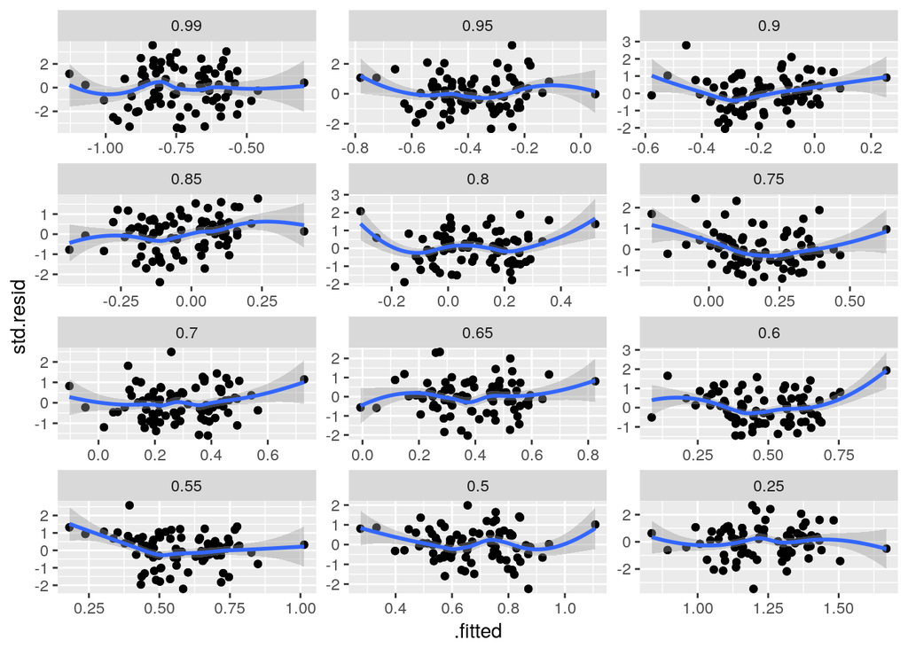

**Figura 2.1** standard resíduos ~ ajustado

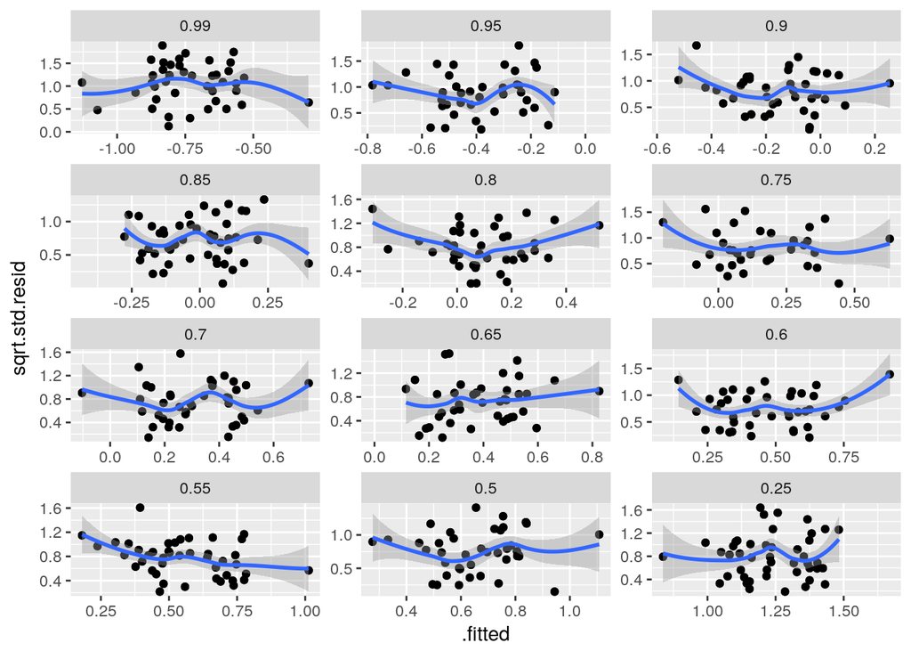

**Figura 2.2** sqrt standard resíduos ~ ajustado

*Tabela efeitos estimados na escala padrão (não na escala log)*

```
##             par.class par.VE  par.value
## DA.z             beta   DA.z  0.8651770
## (Intercept)      alfa k=0.99  0.4800254
## k0.95            alfa k=0.95  2.9486305
## k0.9             alfa  k=0.9  3.6146252
## k0.85            alfa k=0.85  4.1794911
## k0.8             alfa  k=0.8  4.7222410
## k0.75            alfa k=0.75  5.2578802
## k0.7             alfa  k=0.7  5.8093999
## k0.65            alfa k=0.65  6.3961099
## k0.6             alfa  k=0.6  7.0234188
## k0.55            alfa k=0.55  7.7180471
## k0.5             alfa  k=0.5  8.4854431
## k0.25            alfa k=0.25 14.8749015
```

### A partir daqui trabalho a ser feito

0. Continuar análise de d - distância média de dispersão
4. avaliação do modelo selecionado
5. estudo das estimativas e interpretação
1. I = número fundamental da imigração (Etienne 2005)
1. avaliar qual a melhor distribuição de probabilidade
2. avaliar função de ligação
3. seleção de modelos
4. avaliação do modelo selecionado
5. estudo das estimativas e interpretação
2. n_ref = número de SADs réplicas neutras refutadas
1. avaliar qual a melhor distribuição de probabilidade
2. avaliar função de ligação
3. seleção de modelos
4. avaliação do modelo selecionado
5. estudo das estimativas e interpretação
3. U = probabilidade de especiação segundo modelo EE
1. avaliar qual a melhor distribuição de probabilidade
2. avaliar função de ligação
3. seleção de modelos
4. avaliação do modelo selecionado
5. estudo das estimativas e interpretação